# IOOS System Test: [Extreme Events Theme]

(https://github.com/ioos/system-test/wiki/Development-of-Test-Themes#wiki-theme-2-extreme-events): Inundation

### Compare modeled water levels with observations for a specified bounding box

and time period using IOOS recommended service standards for catalog search (CSW) and data retrieval (OPeNDAP & SOS).

- Query CSW to find datasets that match criteria
- Extract OPeNDAP data endpoints from model datasets and SOS endpoints from observational datasets
- OPeNDAP model datasets will be granules
- SOS endpoints may be datasets (from ncSOS) or collections of datasets (from NDBC, CO-OPS SOS servers)
- Filter SOS services to obtain datasets
- Extract data from SOS datasets
- Extract data from model datasets at locations of observations
- Compare time series data on same vertical datum

```python
# Standard Library.
from datetime import datetime, timedelta

# Scientific stack.
import iris
import numpy as np
import cartopy.crs as ccrs
from cartopy.io.img_tiles import MapQuestOpenAerial
from pandas import Panel, DataFrame, concat, read_csv, date_range

# Custom IOOS/ASA modules (available at PyPI).
from owslib import fes
from owslib.csw import CatalogueServiceWeb
from pyoos.collectors.coops.coops_sos import CoopsSos

# Local imports
if False:
    from utilities import name_list, sos_name
    from utilities import (dateRange, service_urls, coops2df,
                           find_timevar, find_ij, mod_df, nearxy)

%run utilities.ipynb
```

### Specify a time range and bounding box of interest:

```python
# Specific specific times (UTC).
dates = {'Hurricane sandy':
         [datetime(2012, 10, 26), datetime(2012, 11, 2)],
         '2014 Feb 10-15 Storm':
         [datetime(2014, 2, 10), datetime(2014, 2, 15)],
         '2014 Recent': [datetime(2014, 3, 8), datetime(2014, 3, 11)],
         '2011': [datetime(2013, 4, 20), datetime(2013, 4, 24)]}
jd_now = datetime.utcnow()
jd_start,  jd_stop = jd_now - timedelta(days=3), jd_now + timedelta(days=3)

start_date = jd_start.strftime('%Y-%m-%d %H:00')
stop_date = jd_stop.strftime('%Y-%m-%d %H:00')

jd_start = datetime.strptime(start_date, '%Y-%m-%d %H:%M')
jd_stop = datetime.strptime(stop_date, '%Y-%m-%d %H:%M')

print('%s to %s' % (start_date, stop_date))
```

```
2014-05-06 22:00 to 2014-05-12 22:00
```

```python
# Bounding Box [lon_min, lat_min, lon_max, lat_max]
area = {'New York harbor region': [-75., 39., -71., 41.5],
        'Gulf of Maine': [-72.0, 41.0, -69.0, 43.0],
        'Hawaii': [-160.0, 18.0, -154., 23.0]}
box = area['New York harbor region']
```

### Search CSW for datasets of interest

```python
website('www.ngdc.noaa.gov/geoportal/', 'CSW datasets')
```

[CSW datasets](http://www.ngdc.noaa.gov/geoportal/)

[interactive chart not shown]

# Connect to CSW, explore it's properties.

```python
CSW = {'NGDC Geoportal': 'http://www.ngdc.noaa.gov/geoportal/csw',
       'USGS WHSC Geoportal': 'http://geoport.whoi.edu/geoportal/csw',
       'NODC Geoportal: granule level': 'http://www.nodc.noaa.gov/geoportal/csw',
       'NODC Geoportal: collection level': 'http://data.nodc.noaa.gov/geoportal/csw',
       'NRCAN CUSTOM': 'http://geodiscover.cgdi.ca/wes/serviceManagerCSW/csw',
       'USGS Woods Hole GI_CAT': 'http://geoport.whoi.edu/gi-cat/services/cswiso',
       'USGS CIDA Geonetwork': 'http://cida.usgs.gov/gdp/geonetwork/srv/en/csw',
       'USGS Coastal and Marine Program': 'http://cmgds.marine.usgs.gov/geonetwork/srv/en/csw',
       'USGS Woods Hole Geoportal': 'http://geoport.whoi.edu/geoportal/csw',
       'CKAN testing site for new Data.gov': 'http://geo.gov.ckan.org/csw',
       'EPA': 'https://edg.epa.gov/metadata/csw',
       'CWIC': 'http://cwic.csiss.gmu.edu/cwicv1/discovery'}

endpoint = CSW['NGDC Geoportal']
csw = CatalogueServiceWeb(endpoint, timeout=60)

print(csw.version)
```

```
2.0.2
```

```python
for operation in csw.operations:
    if operation.name == 'GetRecords':
        print('ISO Queryables:\n%s' %
              '\n'.join(operation.constraints['SupportedISOQueryables']['values']))
```

```
ISO Queryables:
apiso:Subject
apiso:Title
apiso:Abstract
apiso:AnyText
apiso:Format
apiso:Identifier
apiso:Modified
apiso:Type
apiso:BoundingBox
apiso:CRS.Authority
apiso:CRS.ID
apiso:CRS.Version
apiso:RevisionDate
apiso:AlternateTitle
apiso:CreationDate
apiso:PublicationDate
apiso:OrganizationName
apiso:HasSecurityConstraints
apiso:Language
apiso:ResourceIdentifier
apiso:ParentIdentifier
apiso:KeywordType
apiso:TopicCategory
apiso:ResourceLanguage
apiso:GeographicDescriptionCode
apiso:Denominator
apiso:DistanceValue
apiso:DistanceUOM
apiso:TempExtent_begin
apiso:TempExtent_end
apiso:ServiceType
apiso:ServiceTypeVersion
apiso:Operation
apiso:OperatesOn
apiso:OperatesOnIdentifier
apiso:OperatesOnName
apiso:CouplingType
```

# Convert User Input into FES filters.

```python
start, stop = dateRange(start_date, stop_date)
bbox = fes.BBox(box)
```

```python
or_filt = fes.Or([fes.PropertyIsLike(propertyname='apiso:AnyText',
                                     literal=('*%s*' % val),
                                     escapeChar='\\',
                                     wildCard='*',
                                     singleChar='?') for val in name_list])
```

ROMS model output often has Averages and History files. The Averages files are usually averaged over a tidal cycle or more, while the History files are snapshots at that time instant. We are not interested in averaged data for this test, so in the cell below we remove any Averages files here by removing any datasets that have the term "Averages" in the metadata text. A better approach would be to look at the `cell_methods` attributes propagated through to some term in the ISO metadata, but this is not implemented yet, as far as I know.

```python
val = 'Averages'
not_filt = fes.Not([fes.PropertyIsLike(propertyname='apiso:AnyText',
                                       literal=('*%s*' % val),
                                       escapeChar='\\',
                                       wildCard='*',
                                       singleChar='?')])

filter_list = [fes.And([bbox, start, stop, or_filt, not_filt])]
```

Try request using multiple filters "and" syntax: [[filter1, filter2]].

```python
csw.getrecords2(constraints=filter_list, maxrecords=1000, esn='full')
print(len(csw.records.keys()))
```

```
15
```

Now print out some titles

```python
for rec, item in csw.records.iteritems():
    print(item.title)
```

```
NYHOPS Forecast Model Results
ROMS ESPRESSO Real-Time Operational IS4DVAR Forecast System Version 2 (NEW) 2013-present FMRC History (Best)
NECOFS GOM3 (FVCOM) - Northeast US - Latest Forecast
NECOFS GOM3 Wave - Northeast US - Latest Forecast
DBOFS - Delaware Bay Operational Forecast System - NOAA CO-OPS - POM
NYOFS - New York and New Jersey Operational Forecast System - NOAA CO-OPS - POM
COAWST Forecast System : USGS : US East Coast and Gulf of Mexico (Experimental)
Barotropic Tide Model for the Pacific Basin
CBOFS - Chesapeake Bay Operational Forecast System - NOAA CO-OPS - POM
ESTOFS Storm Surge Model - Atlantic - v1.0.0 - NOAA - NCEP - ADCIRC
NECOFS Massachusetts (FVCOM) - Massachusetts Coastal - Latest Forecast
HYbrid Coordinate Ocean Model (HYCOM): Global
HRECOS Aggregated Station HRWSTPTH Data
HRECOS Aggregated Station HRPIER84 Data
HRECOS Aggregated Station HRPMNTH Data
```

## 1. Get observations from SOS

Here we are using a custom class from pyoos to read the CO-OPS SOS. This is definitely unsavory, as the whole point of using a standard is avoid the need for custom classes for each service. Need to examine the consequences of removing this and just going with straight SOS service using OWSLib.

```python
collector = CoopsSos()
collector.datum = 'NAVD'  # 'MSL'
```

```python
print(collector.server.identification.title)
```

```
NOAA.NOS.CO-OPS SOS
```

```python
collector.start_time = jd_start
collector.end_time = jd_stop
collector.variables = [sos_name]
```

```python
ofrs = collector.server.offerings
```

```python
print(len(ofrs))
for p in ofrs[700:710]:
    print(p)
```

```
1028
Offering id: station-8311062, name: urn:ioos:station:NOAA.NOS.CO-OPS:8311062
Offering id: station-8410140, name: urn:ioos:station:NOAA.NOS.CO-OPS:8410140
Offering id: station-8411060, name: urn:ioos:station:NOAA.NOS.CO-OPS:8411060
Offering id: station-8413320, name: urn:ioos:station:NOAA.NOS.CO-OPS:8413320
Offering id: station-8418150, name: urn:ioos:station:NOAA.NOS.CO-OPS:8418150
Offering id: station-8419317, name: urn:ioos:station:NOAA.NOS.CO-OPS:8419317
Offering id: station-8423898, name: urn:ioos:station:NOAA.NOS.CO-OPS:8423898
Offering id: station-8443970, name: urn:ioos:station:NOAA.NOS.CO-OPS:8443970
Offering id: station-8447386, name: urn:ioos:station:NOAA.NOS.CO-OPS:8447386
Offering id: station-8447387, name: urn:ioos:station:NOAA.NOS.CO-OPS:8447387
```

### Find the SOS stations within our bounding box and time extent

We would like to just use a filter on a collection to get a new collection, but PYOOS doesn't do that yet. So we do a GetObservation request for a collection, including a bounding box, and asking for one value at the start of the time period of interest. We use that to do a bounding box filter on the SOS server, which returns 1 point for each station found. So for 3 stations, we get back 3 records, in CSV format. We can strip the station ids from the CSV, and then we have a list of stations we can use with pyoos. The template for the GetObservation query for the bounding box filtered collection was generated using the GUI at http://opendap.co-ops.nos.noaa.gov/ioos-dif-sos/

```python
iso_start = jd_start.strftime('%Y-%m-%dT%H:%M:%SZ')
box_str = ','.join(str(e) for e in box)
print('Start date:\t%s\nBoundary box:\t%s' % (iso_start, box_str))
```

```
Start date:	2014-05-06T22:00:00Z
Boundary box:	-75.0,39.0,-71.0,41.5
```

```python
url = (('http://opendap.co-ops.nos.noaa.gov/ioos-dif-sos/SOS?'
        'service=SOS&request=GetObservation&version=1.0.0&'
        'observedProperty=%s&offering='
        'urn:ioos:network:NOAA.NOS.CO-OPS:WaterLevelActive&'
        'featureOfInterest=BBOX:%s&responseFormat=text/csv&eventTime=%s') %
       (sos_name, box_str, iso_start))

print(url)
obs_loc_df = read_csv(url)
```

[output not shown]

```python
# Clean-up some names:
obs_loc_df['station_id'] = [sta.split(':')[-1] for sta in obs_loc_df['station_id']]
obs_loc_df['sensor_id'] = [sta.split(':')[-1] for sta in obs_loc_df['sensor_id']]
obs_loc_df['datum_id'] = [sta.split(':')[-1] for sta in obs_loc_df['datum_id']]

obs_loc_df.head()
```

|  | station_id | sensor_id | latitude (degree) | longitude (degree) | date_time | water_surface_height_above_reference_datum (m) | datum_id | vertical_position (m) |
| --- | --- | --- | --- | --- | --- | --- | --- | --- |
| 0 | 8461490 | A1 | 41.3614 | -72.0900 | 2014-05-06T22:00:00Z | 0.746 | MLLW | 1.074 |
| 1 | 8465705 | A1 | 41.2833 | -72.9083 | 2014-05-06T22:00:00Z | 1.846 | MLLW | 5.618 |
| 2 | 8467150 | A1 | 41.1733 | -73.1817 | 2014-05-06T22:00:00Z | 1.996 | MLLW | 0.604 |
| 3 | 8510560 | A1 | 41.0483 | -71.9600 | 2014-05-06T22:00:00Z | 0.612 | MLLW | 1.177 |
| 4 | 8516945 | A1 | 40.8103 | -73.7649 | 2014-05-06T22:00:00Z | 2.158 | MLLW | 3.928 |

5 rows × 8 columns

```python
names = [get_Coops_longName(sta) for sta in obs_loc_df['station_id']]
stations = dict(zip(obs_loc_df['station_id'],
                    zip(names,
                        zip(obs_loc_df['longitude (degree)'],
                            obs_loc_df['latitude (degree)']))))
stations
```

```
{'8461490': ('New London, CT', (-72.090000000000003, 41.361400000000003)),
 '8465705': ('New Haven, CT', (-72.908299999999997, 41.283299999999997)),
 '8467150': ('Bridgeport, CT', (-73.181700000000006, 41.173299999999998)),
 '8510560': ('Montauk, NY', (-71.959999999999994, 41.048299999999998)),
 '8516945': ('Kings Point, NY', (-73.764899999999997, 40.810299999999998)),
 '8518750': ('The Battery, NY', (-74.014200000000002, 40.700600000000001)),
 '8519483': ('Bergen Point West Reach, NY', (-74.1417, 40.636699999999998)),
 '8531680': ('Sandy Hook, NJ', (-74.009399999999999, 40.466900000000003)),
 '8534720': ('Atlantic City, NJ', (-74.418300000000002, 39.354999999999997)),
 '8539094': ('Burlington, Delaware River, NJ',
  (-74.869699999999995, 40.081699999999998)),
 '8548989': ('Newbold, PA', (-74.7517, 40.136699999999998))}
```

Generate a uniform 6-min time base for model/data comparison:

```python
ts_rng = date_range(start=jd_start, end=jd_stop, freq='6Min')
ts = DataFrame(index=ts_rng)
print(jd_start, jd_stop)
print(len(ts))
```

```
(datetime.datetime(2014, 5, 6, 22, 0), datetime.datetime(2014, 5, 12, 22, 0))
1441
```

Create a list of obs dataframes, one for each station:

```python
obs_df = []
sta_failed = []
for sta in stations:
    b = coops2df(collector, sta, sos_name)
    if b.empty:
        sta_failed.append(b.name)
    else:
        print(b.name)
        # Limit interpolation to 10 points (10 @ 6min = 1 hour).
        col = 'Observed Data'
        obs_df.append(DataFrame(concat([b, ts],
                                       axis=1).interpolate(limit=10)[col]))
        obs_df[-1].name = b.name
```

```
Sandy Hook, NJ
Atlantic City, NJ
New London, CT
Bridgeport, CT
Montauk, NY
The Battery, NY
```

```python
import matplotlib.pyplot as plt
from matplotlib.transforms import offset_copy
def make_map(datum='WGS84', zoom=8, figsize=(10, 10)):
    geodetic = ccrs.Geodetic(globe=ccrs.Globe(datum=datum))
    tiler = MapQuestOpenAerial()
    fig, ax = plt.subplots(figsize=figsize,
                           subplot_kw=dict(projection=tiler.crs))
    extent = [box[0], box[2], box[1], box[3]]
    ax.set_extent(extent, geodetic)
    ax.add_image(tiler, zoom)
    ax.set_title('Water Level Gauge Locations')
    gl = ax.gridlines(draw_labels=True)
    gl.xlabels_top = gl.ylabels_right = False
    return fig, ax
```

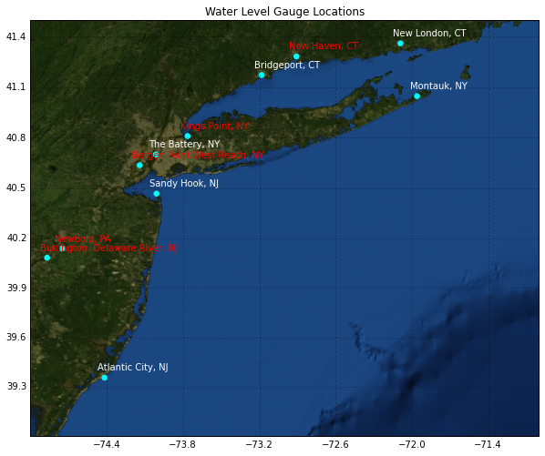

```python
zoom = 8
fig, ax = make_map(zoom=zoom)
kw = dict(marker='o', s=30, color='cyan', transform=ccrs.PlateCarree())
ax.scatter(obs_loc_df['longitude (degree)'], obs_loc_df['latitude (degree)'], **kw)
geodetic_transform = ccrs.Geodetic()._as_mpl_transform(ax)
text_transform = offset_copy(geodetic_transform, units='dots', x=-zoom, y=+zoom)

kw = dict(horizontalalignment='left', transform=text_transform,)
for station in stations.items():
    number, (name, (lon, lat)) = station
    if name in sta_failed:
        color = 'red'
    else:
        color = 'white'
    ax.text(lon, lat, name, color=color, **kw)
```

### Get model output from OPeNDAP URLS

Try to open all the OPeNDAP URLS using Iris from the British Met Office. If 1D, assume dataset is data, if 2D assume dataset is an unstructured grid model, and if 3D, assume it's a structured grid model.

Construct an Iris contraint to load only cubes that match the std_name_list:

```python
name_in_list = lambda cube: cube.standard_name in name_list
constraint = iris.Constraint(cube_func=name_in_list)
print('\n'.join(name_list))
```

```
water_surface_height_above_reference_datum
sea_surface_height_above_geoid
sea_surface_elevation
sea_surface_height_above_reference_ellipsoid
sea_surface_height_above_sea_level
sea_surface_height
water level
```

### Use only data within 0.04 degrees (about 4 km).

```python
max_dist = 0.04
```

### Use only data where the standard deviation of the time series exceeds 0.01 m (1 cm) this eliminates flat line model time series that come from land points that should have had missing values.

```python
min_var = 0.01
```

### Loop through all dap url.

```python
print('\n'.join(dap_urls))
```

```
http://colossus.dl.stevens-tech.edu/thredds/dodsC/latest/Complete_gcmplt.nc
http://tds.marine.rutgers.edu/thredds/dodsC/roms/espresso/2013_da/his_Best/ESPRESSO_Real-Time_v2_History_Best_Available_best.ncd
http://www.smast.umassd.edu:8080/thredds/dodsC/FVCOM/NECOFS/Forecasts/NECOFS_GOM3_FORECAST.nc
http://www.smast.umassd.edu:8080/thredds/dodsC/FVCOM/NECOFS/Forecasts/NECOFS_WAVE_FORECAST.nc
http://opendap.co-ops.nos.noaa.gov/thredds/dodsC/DBOFS/fmrc/Aggregated_7_day_DBOFS_Fields_Forecast_best.ncd
http://opendap.co-ops.nos.noaa.gov/thredds/dodsC/NYOFS/fmrc/Aggregated_7_day_NYOFS_Fields_Forecast_best.ncd
http://geoport.whoi.edu/thredds/dodsC/coawst_4/use/fmrc/coawst_4_use_best.ncd
http://oos.soest.hawaii.edu/thredds/dodsC/hioos/tide_pac
http://opendap.co-ops.nos.noaa.gov/thredds/dodsC/CBOFS/fmrc/Aggregated_7_day_CBOFS_Fields_Forecast_best.ncd
http://geoport-dev.whoi.edu/thredds/dodsC/estofs/atlantic
http://www.smast.umassd.edu:8080/thredds/dodsC/FVCOM/NECOFS/Forecasts/NECOFS_FVCOM_OCEAN_MASSBAY_FORECAST.nc
http://oos.soest.hawaii.edu/thredds/dodsC/pacioos/hycom/global
http://sos.maracoos.org/stable/dodsC/stationHRWSTPTH-agg.ncml
http://sos.maracoos.org/stable/dodsC/stationHRPIER84-agg.ncml
http://sos.maracoos.org/stable/dodsC/stationHRPMNTH-agg.ncml
```

```python
def load_dap(url, constraint):
    """Modifies obs_df to include model data."""
    cube = iris.load_cube(url, constraint)
    # Convert to units of meters.
    # FIXME: cube.convert_units('m') is not working for unstructured data!
    # Take first 20 chars for model name.
    mod_name = cube.attributes['title'][0:20]
    lat = cube.coord(axis='Y').points
    lon = cube.coord(axis='X').points
    time = find_timevar(cube)
    jd = time.units.num2date(time.points)
    istart = time.nearest_neighbour_index(time.units.date2num(jd_start))
    istop = time.nearest_neighbour_index(time.units.date2num(jd_stop))

    # Only proceed if we have data in the range requested.
    if istart != istop:
        nsta = len(obs_loc_df['longitude (degree)'])
        if len(cube.shape) == 3:
            print('[Structured grid model]: %s' % url)
            model_type = 'structured'
        elif len(cube.shape) == 2:
            print('[Unstructured grid model]:%s' % url)
            model_type = 'unstructured'
        elif len(cube.shape) == 1:
            print('[Data]:%s' % url)
            model_type = 'data'
        else:
            print('Unrecognized cube shape: %s' % cube.shape)
            model_type = None

        # Find the closest non-land point from a structured grid model.
        if model_type == 'structured':
            if len(lon.shape) == 1:
                lon, lat = np.meshgrid(lon, lat)
                j, i, dd = find_ij(lon, lat, cube[0, ...].data,
                                   obs_loc_df['longitude (degree)'].values,
                                   obs_loc_df['latitude (degree)'].values)
            for n in range(nsta):
                # Only use cell is within 0.1 degree of requested location.
                if dd[n] <= max_dist:
                    arr = cube[istart:istop, j[n], i[n]].data
                    if arr.std() >= min_var:
                        model_df = mod_df(arr, time, istart, istop, mod_name, ts)
                        name = obs_df[n].name
                        obs_df[n] = concat([obs_df[n], model_df], axis=1)
                        obs_df[n].name = name

        # Find the closest point from an unstructured grid model.
        if model_type == 'unstructured':
            i, dd = nearxy(lon.flatten(), lat.flatten(),
                                obs_loc_df['longitude (degree)'],
                                obs_loc_df['latitude (degree)'])
            for n in range(nsta):
                # Only use cell is within 0.1 degree of requested location.
                if dd[n] <= max_dist:
                    arr = cube[istart:istop, i[n]].data
                    if arr.std() >= min_var:
                        model_df = mod_df(arr, time, istart, istop, mod_name, ts)
                        name = obs_df[n].name
                        obs_df[n] = concat([obs_df[n], model_df], axis=1)
                        obs_df[n].name = name
    return obs_df
```

```python
for url in dap_urls:
    try:
        print(url)
        obs_df = load_dap(url, constraint)
    except:
        pass
```

```
http://colossus.dl.stevens-tech.edu/thredds/dodsC/latest/Complete_gcmplt.nc
http://tds.marine.rutgers.edu/thredds/dodsC/roms/espresso/2013_da/his_Best/ESPRESSO_Real-Time_v2_History_Best_Available_best.ncd
[Structured grid model]: http://tds.marine.rutgers.edu/thredds/dodsC/roms/espresso/2013_da/his_Best/ESPRESSO_Real-Time_v2_History_Best_Available_best.ncd
http://www.smast.umassd.edu:8080/thredds/dodsC/FVCOM/NECOFS/Forecasts/NECOFS_GOM3_FORECAST.nc
[Unstructured grid model]:http://www.smast.umassd.edu:8080/thredds/dodsC/FVCOM/NECOFS/Forecasts/NECOFS_GOM3_FORECAST.nc
http://www.smast.umassd.edu:8080/thredds/dodsC/FVCOM/NECOFS/Forecasts/NECOFS_WAVE_FORECAST.nc
http://opendap.co-ops.nos.noaa.gov/thredds/dodsC/DBOFS/fmrc/Aggregated_7_day_DBOFS_Fields_Forecast_best.ncd
[Structured grid model]: http://opendap.co-ops.nos.noaa.gov/thredds/dodsC/DBOFS/fmrc/Aggregated_7_day_DBOFS_Fields_Forecast_best.ncd
http://opendap.co-ops.nos.noaa.gov/thredds/dodsC/NYOFS/fmrc/Aggregated_7_day_NYOFS_Fields_Forecast_best.ncd
[Structured grid model]: http://opendap.co-ops.nos.noaa.gov/thredds/dodsC/NYOFS/fmrc/Aggregated_7_day_NYOFS_Fields_Forecast_best.ncd
http://geoport.whoi.edu/thredds/dodsC/coawst_4/use/fmrc/coawst_4_use_best.ncd
[Structured grid model]: http://geoport.whoi.edu/thredds/dodsC/coawst_4/use/fmrc/coawst_4_use_best.ncd
http://oos.soest.hawaii.edu/thredds/dodsC/hioos/tide_pac
[Structured grid model]: http://oos.soest.hawaii.edu/thredds/dodsC/hioos/tide_pac
http://opendap.co-ops.nos.noaa.gov/thredds/dodsC/CBOFS/fmrc/Aggregated_7_day_CBOFS_Fields_Forecast_best.ncd
[Structured grid model]: http://opendap.co-ops.nos.noaa.gov/thredds/dodsC/CBOFS/fmrc/Aggregated_7_day_CBOFS_Fields_Forecast_best.ncd
http://geoport-dev.whoi.edu/thredds/dodsC/estofs/atlantic
[Unstructured grid model]:http://geoport-dev.whoi.edu/thredds/dodsC/estofs/atlantic
http://www.smast.umassd.edu:8080/thredds/dodsC/FVCOM/NECOFS/Forecasts/NECOFS_FVCOM_OCEAN_MASSBAY_FORECAST.nc
[Unstructured grid model]:http://www.smast.umassd.edu:8080/thredds/dodsC/FVCOM/NECOFS/Forecasts/NECOFS_FVCOM_OCEAN_MASSBAY_FORECAST.nc
http://oos.soest.hawaii.edu/thredds/dodsC/pacioos/hycom/global
[Structured grid model]: http://oos.soest.hawaii.edu/thredds/dodsC/pacioos/hycom/global
http://sos.maracoos.org/stable/dodsC/stationHRWSTPTH-agg.ncml
http://sos.maracoos.org/stable/dodsC/stationHRPIER84-agg.ncml
http://sos.maracoos.org/stable/dodsC/stationHRPMNTH-agg.ncml
```

[output not shown]

[output not shown]

```python
panel = dict()
for df in obs_df:
    panel.update({df.name: df})

dfs = Panel.from_dict(panel)
```

[output not shown]

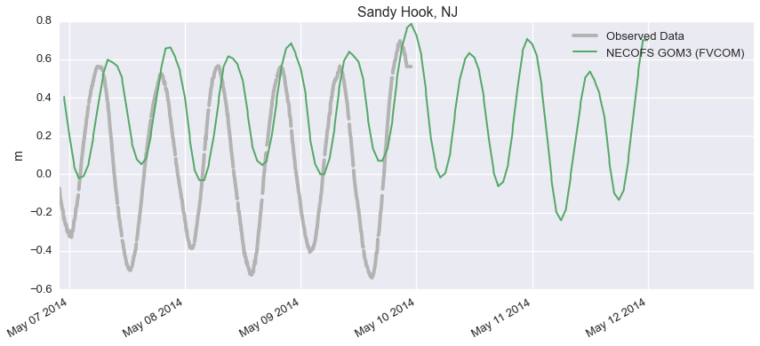

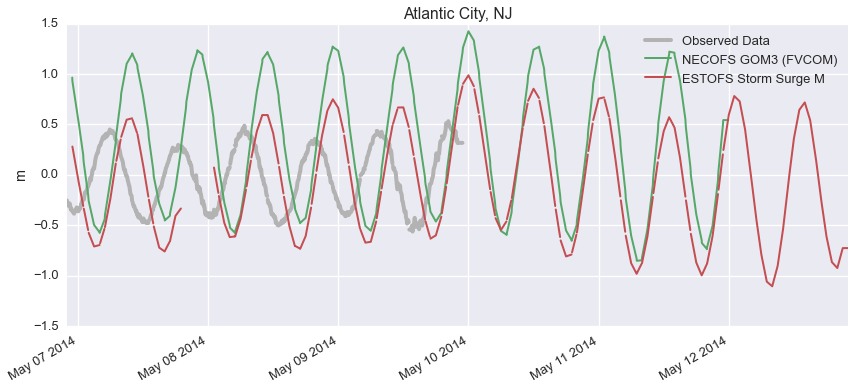

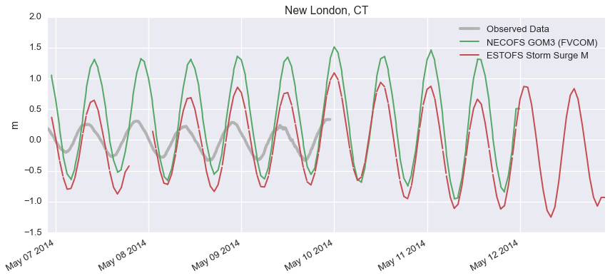

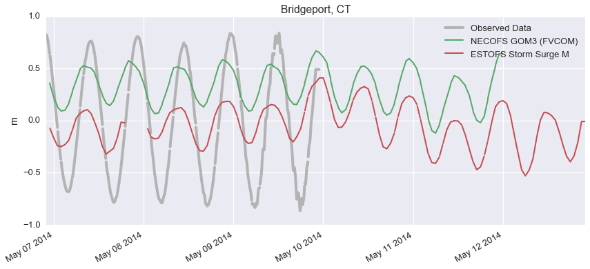

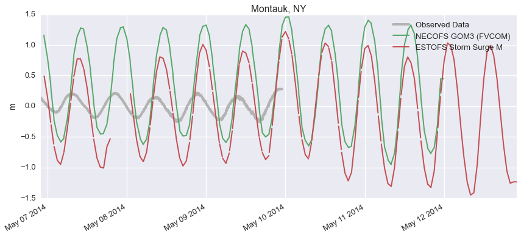

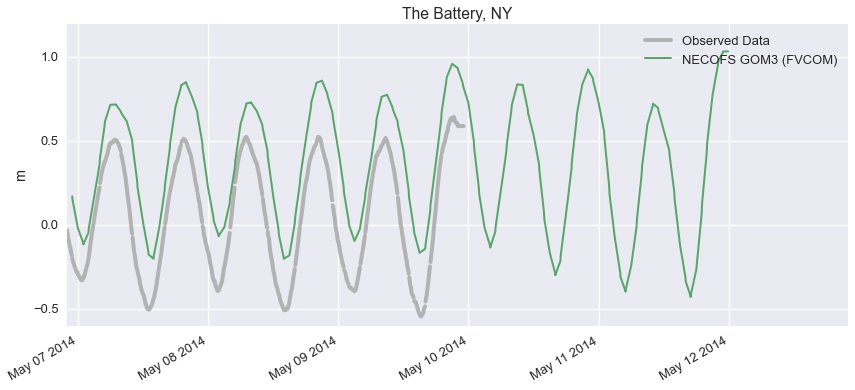

```python
for df in obs_df:
    ax = df.plot(figsize=(14, 6), title=df.name, legend=False)
    plt.setp(ax.lines[0], linewidth=4.0, color='.7', zorder=1)
    ax.legend()
    ax.set_ylabel('m')
```

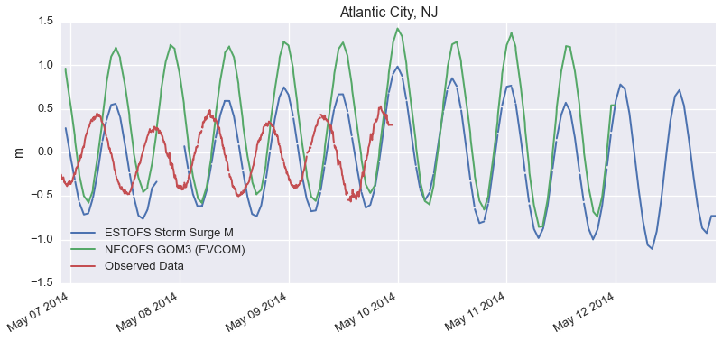

```python
name = 'Atlantic City, NJ'
ax = dfs[name].plot(figsize=(13, 5.75), title=name, legend=True)
_ = ax.set_ylabel('m')
```

```python
vals = dfs.loc[:, jd_start:jd_stop, :]  # Not necessary, the axis are already in the time interval.
amean = vals.mean()
amean.ix['Observed Data'] - amean
```

|  | Atlantic City, NJ | Bridgeport, CT | Montauk, NY | New London, CT | Sandy Hook, NJ | The Battery, NY |
| --- | --- | --- | --- | --- | --- | --- |
| ESTOFS Storm Surge M | 0.062111 | 0.040395 | 0.112492 | 0.087856 | NaN | NaN |
| NECOFS GOM3 (FVCOM) | -0.331590 | -0.333254 | -0.325320 | -0.318112 | -0.246103 | -0.302417 |
| Observed Data | 0.000000 | 0.000000 | 0.000000 | 0.000000 | 0.000000 | 0.000000 |

3 rows × 6 columns